# Análise Exploratória de Dados - InteliFalhas.csv

Yago Araújo

2025-02-08

## Introdução

Este relatório apresenta uma análise exploratória de dados com base no arquivo “InteliFalhas.csv”.

O objetivo é explorar as principais características dos dados, identificar relações entre variáveis e discutir descobertas relevantes.

## 1. Carregamento e Preparação dos Dados

### Carregamento dos Dados

Agora, vamos carregar os dados do arquivo CSV e visualizar as primeiras linhas para entender sua estrutura.

```r
# Carregar bibliotecas
library(readr)
library(dplyr)
```

```r
library(ggplot2)
library(corrplot)
data <- read.csv("./inteliFalhas.csv")

# Visualizar as primeiras linhas
head(data)
```

```
##             ID              DATA.DETECCAO   PONTO   LOC_ID
## 1 2024-3712154 2010-01-29-02.25.25.000000 RODAGEM     5559
## 2 2024-3722068 2010-01-29-02.38.57.000000 RODAGEM     5559
## 3 2024-3732080 2010-01-29-02.44.54.000000 RODAGEM     7057
## 4 2024-3732079 2010-01-29-02.53.28.000000 RODAGEM     5851
## 5 2024-3711076 2010-01-29-02.54.22.000000 RODAGEM     4661
## 6 2024-3732094 2010-01-29-04.04.56.000000 RODAGEM 98761528
##                                      LOC POS_ID      POS TYPE_ID
## 1                         Tampa traseira     -2               70
## 2                         Tampa traseira     -2               70
## 3                  Revestimento coluna A      5  direita      70
## 4                         Porta traseira      5  direita      70
## 5               Alavanca do freio manual     -2                5
## 6 Regulador de altura cinto de segurança      3 esquerda      31
##                                   TYPE_TEXT VIEW_ID COLUNA LINHA
## 1                               070 - Ruído      NA           NA
## 2                               070 - Ruído      NA           NA
## 3                               070 - Ruído      NA           NA
## 4                               070 - Ruído      NA           NA
## 5                           005 - Baixo (a)      NA           NA
## 6 031 - Parcialmente sem fun\\u00e7\\u00e3o      NA           NA
```

### Verificação da Estrutura dos Dados

Vamos verificar a estrutura dos dados, identificando os tipos de cada coluna e conferindo se há colunas numéricas que podemos analisar mais a fundo.

```r
str(data)
```

```
## 'data.frame':    679073 obs. of  12 variables:
##  $ ID           : chr  "2024-3712154" "2024-3722068" "2024-3732080" "2024-3732079" ...
##  $ DATA.DETECCAO: chr  "2010-01-29-02.25.25.000000" "2010-01-29-02.38.57.000000" "2010-01-29-02.44.54.000000" "2010-01-29-02.53.28.000000" ...
##  $ PONTO        : chr  "RODAGEM" "RODAGEM" "RODAGEM" "RODAGEM" ...
##  $ LOC_ID       : int  5559 5559 7057 5851 4661 98761528 51371 5851 7018 4200 ...
##  $ LOC          : chr  "Tampa traseira" "Tampa traseira" "Revestimento coluna A" "Porta traseira" ...
##  $ POS_ID       : int  -2 -2 5 5 -2 3 3 5 4 3 ...
##  $ POS          : chr  "" "" "direita" "direita" ...
##  $ TYPE_ID      : int  70 70 70 70 5 31 70 70 70 70 ...
##  $ TYPE_TEXT    : chr  "070 - Ruído" "070 - Ruído" "070 - Ruído" "070 - Ruído" ...
##  $ VIEW_ID      : num  NA NA NA NA NA NA NA NA NA NA ...
##  $ COLUNA       : chr  "" "" "" "" ...
##  $ LINHA        : int  NA NA NA NA NA NA NA NA NA NA ...
```

## 2. Resumo Estatístico e Descrição dos Dados

### Resumo Estatístico

Agora, vamos gerar um resumo estatístico dos dados para entender as distribuições de cada variável numérica, como médias, medianas e quartis.

```r
summary(data)
```

```
##       ID            DATA.DETECCAO         PONTO               LOC_ID
##  Length:679073      Length:679073      Length:679073      Min.   :    1001
##  Class :character   Class :character   Class :character   1st Qu.:    5145
##  Mode  :character   Mode  :character   Mode  :character   Median :    5559
##                                                           Mean   : 3520407
##                                                           3rd Qu.:    5851
##                                                           Max.   :99008995
##
##      LOC                POS_ID            POS               TYPE_ID
##  Length:679073      Min.   :     -2   Length:679073      Min.   :       1
##  Class :character   1st Qu.:      1   Class :character   1st Qu.:      39
##  Mode  :character   Median :     10   Mode  :character   Median :      89
##                     Mean   :  49464                      Mean   : 5766978
##                     3rd Qu.:     17                      3rd Qu.:     126
##                     Max.   :9799976                      Max.   :99008934
##
##   TYPE_TEXT            VIEW_ID         COLUNA              LINHA
##  Length:679073      Min.   :661.0   Length:679073      Min.   :1.00
##  Class :character   1st Qu.:673.0   Class :character   1st Qu.:2.00
##  Mode  :character   Median :689.0   Mode  :character   Median :3.00
##                     Mean   :699.3                      Mean   :3.25
##                     3rd Qu.:723.0                      3rd Qu.:4.00
##                     Max.   :778.0                      Max.   :6.00
##                     NA's   :98563                      NA's   :98564
```

#### Descrição das Variáveis

- ID: Identificador único do registro
- DATA.DETECCAO: Data em que a falha foi detectada
- PONTO: Ponto específico da análise
- LOC_ID: ID da localização
- LOC: Descrição da localização
- POS_ID: ID da posição
- POS: Descrição da posição
- TYPE_ID: ID do tipo de falha
- TYPE_TEXT: Descrição textual do tipo de falha
- VIEW_ID: Identificador da visualização
- COLUNA: Coluna da falha
- LINHA: Linha da falha

## 3. Análise Univariada

### Distribuição das Variáveis

Agora, vamos analisar a distribuição da variável LOC_ID, visualizando a quantidade de ocorrências de cada valor dessa variável.

```
## Valores únicos encontrados na coluna após conversão:
##   [1]     5559     7057     5851     4661 98761528    51371     7018     4200
##   [9]    53002     5355     5751     5055     5305     5103     5141     5522
##  [17]     5145    58510    50001    57510     5142  9803735    72631     7209
##  [25]    72554 99006313     2706 98735183 98762925    94312     6350 98762015
##  [33]  9792711    51731  9801225     6817     6445 98735182 98735262    64481
##  [41] 98735263 98753237     7084  9789856     7067     6310     3405     5056
##  [49]  9840340    70634 98760932     7068     6465     5147     7059    70672
##  [57] 98765281     7073    64681 98735032    85222 98763458   517311 98751383
##  [65]     6460    53001  9789867  9794120     5763 98753236 98764035    92661
##  [73]    70682     7092 98761892    20102    66503     9415 98753234  9841548
##  [81] 98754407 98753372  9840347     5537    20441     7041     9646    72555
##  [89]     6912 99006283     5845  9789853 98761139  9790695    70571     8553
##  [97]     6679    66041  9790689     6410 98751385  9802939 98759977  9840807
## [105]     4810 98759931 98759942 98760018    97271  9789977     6485 98762927
```

[output cut: 64 more lines]

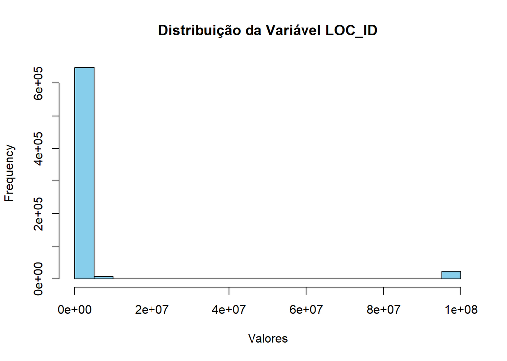

```r
# Verifica se a variável existe no dataset
if ("LOC_ID" %in% colnames(data)) {

  # Remover espaços e converter para numérico, mantendo valores válidos
  data$LOC_ID <- suppressWarnings(as.numeric(gsub(",", ".", gsub(" ", "", as.character(data$LOC_ID)))))

  # Checar se a conversão foi bem-sucedida (se há valores numéricos válidos)
  if (all(is.na(data$LOC_ID))) {
    cat("Erro: Todos os valores da variável 'LOC_ID' são inválidos após a conversão. Verifique os dados.\n")
  } else {
    # Mostrar os valores únicos após a conversão
    cat("Valores únicos encontrados na coluna após conversão:\n")
    print(unique(data$LOC_ID))

    # Gerar histograma
    hist(data$LOC_ID, main = "Distribuição da Variável LOC_ID",
         xlab = "Valores", col = "skyblue")
  }

} else {
  cat("Erro: A coluna 'LOC_ID' não foi encontrada no dataset.\n")
}
```

### Identificação de Outliers

Vamos identificar a presença de outliers na variável LOC_ID por meio de um boxplot.

```
## Valores únicos encontrados na coluna após conversão:
##   [1]     5559     7057     5851     4661 98761528    51371     7018     4200
##   [9]    53002     5355     5751     5055     5305     5103     5141     5522
##  [17]     5145    58510    50001    57510     5142  9803735    72631     7209
##  [25]    72554 99006313     2706 98735183 98762925    94312     6350 98762015
##  [33]  9792711    51731  9801225     6817     6445 98735182 98735262    64481
##  [41] 98735263 98753237     7084  9789856     7067     6310     3405     5056
##  [49]  9840340    70634 98760932     7068     6465     5147     7059    70672
##  [57] 98765281     7073    64681 98735032    85222 98763458   517311 98751383
##  [65]     6460    53001  9789867  9794120     5763 98753236 98764035    92661
##  [73]    70682     7092 98761892    20102    66503     9415 98753234  9841548
##  [81] 98754407 98753372  9840347     5537    20441     7041     9646    72555
##  [89]     6912 99006283     5845  9789853 98761139  9790695    70571     8553
##  [97]     6679    66041  9790689     6410 98751385  9802939 98759977  9840807
## [105]     4810 98759931 98759942 98760018    97271  9789977     6485 98762927
```

[output cut: 64 more lines]

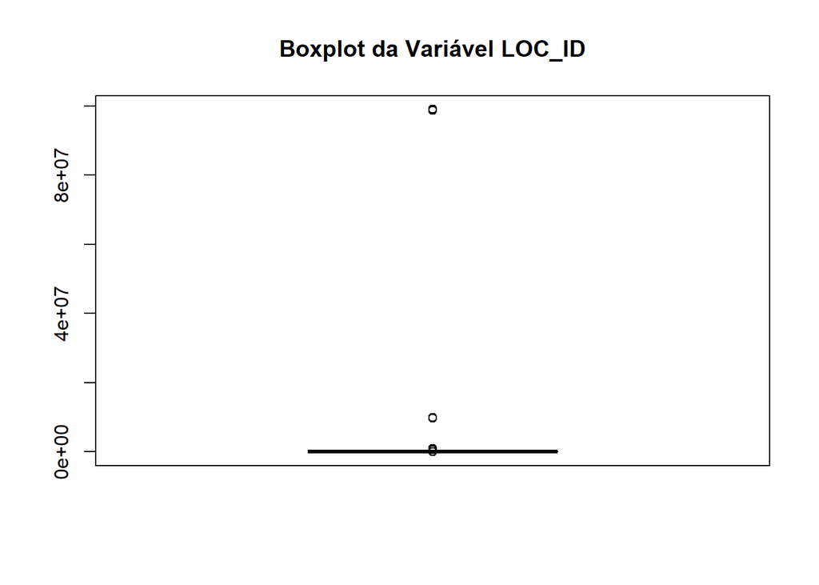

```r
  # Remover espaços e converter para numérico, mantendo valores válidos
  data$LOC_ID <- suppressWarnings(as.numeric(gsub(",", ".", gsub(" ", "", as.character(data$LOC_ID)))))

  # Checar se a conversão foi bem-sucedida (se há valores numéricos válidos)
  if (all(is.na(data$LOC_ID))) {
    cat("Erro: Todos os valores da variável 'LOC_ID' são inválidos após a conversão. Verifique os dados.\n")
  } else {
    # Mostrar os valores únicos após a conversão
    cat("Valores únicos encontrados na coluna após conversão:\n")
    print(unique(data$LOC_ID))

    # Gerar boxplot
    boxplot(data$LOC_ID, main="Boxplot da Variável LOC_ID", col="tomato")
  }
```

## 4. Análise Bivariada

### Relação entre Variáveis

Agora, vamos analisar a relação entre as variáveis LOC_ID e POS_ID através de um gráfico de dispersão para ver se há uma correlação visual.

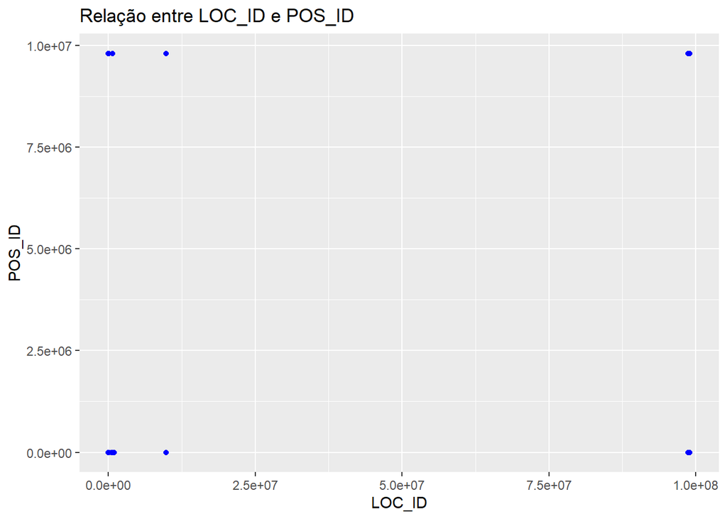

```r
ggplot(data, aes(x = LOC_ID, y = POS_ID)) +
  geom_point(color = "blue") +
  labs(title = "Relação entre LOC_ID e POS_ID", x = "LOC_ID", y = "POS_ID")
```

### Análise de Correlação

Agora, vamos calcular e visualizar a correlação entre todas as variáveis numéricas presentes no dataset, o que pode nos ajudar a identificar relações fortes entre elas.

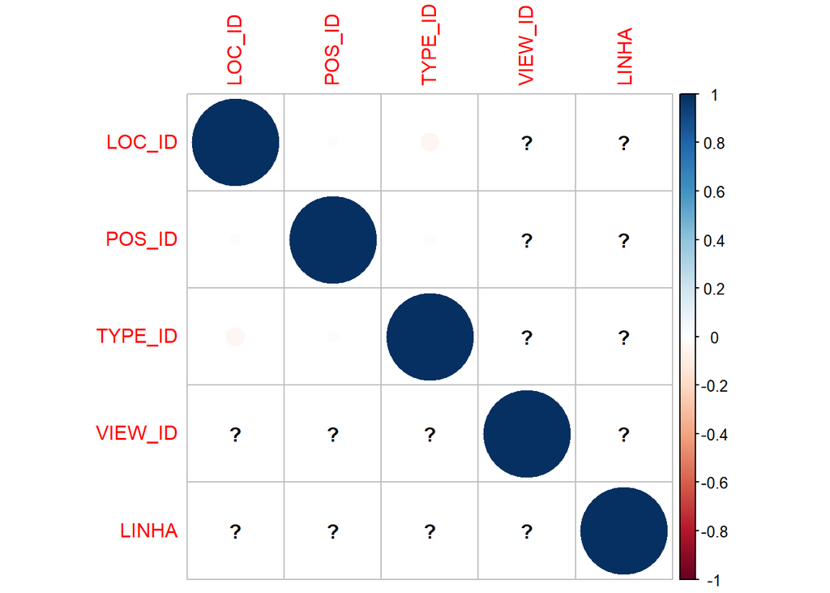

```r
corr_matrix <- cor(data[, sapply(data, is.numeric)])
corrplot(corr_matrix, method="circle")
```